# Homework 10

Małgorzata Pujszo

Wednesday, December 16, 2015

### Performing post-hoc

First task was to perform post-hoc analysis of the effect of ICD10 in eunomia study. I used LSD.test.

```r
library(PBImisc)
library(agricolae)
library(lattice)
library(ggplot2)
library(lme4)
model <- lm(BPRS.T2 ~ ICD10, data=eunomia)
LSD.test(model, "ICD10", console=TRUE)
```

```
##
## Study: model ~ "ICD10"
##
## LSD t Test for BPRS.T2
##
## Mean Square Error:  0.2663032
##
## ICD10,  means and individual ( 95 %) CI
##
##        BPRS.T2        std   r         LCL      UCL      Min      Max
## F04.0 2.791667         NA   1  1.77958053 3.803753 2.791667 2.791667
## F05.0 1.000000         NA   1 -0.01208614 2.012086 1.000000 1.000000
## F05.1 1.333333 0.00000000   2  0.61768036 2.048986 1.333333 1.333333
## F05.8 1.208333         NA   1  0.19624720 2.220419 1.208333 1.208333
## F06.0 1.437500 0.44194174   2  0.72184703 2.153153 1.125000 1.750000
## F06.2 1.811275 0.75964825  17  1.56580757 2.056741 1.083333 4.166667
## F06.3 1.614583 0.50432160   8  1.25675685 1.972410 1.041667 2.541667
## F06.8 1.350000         NA   1  0.33791386 2.362086 1.350000 1.350000
## F07.0 1.458333 0.38036289   4  0.95229026 1.964376 1.000000 1.791667
## F07.7 1.375000         NA   1  0.36291386 2.387086 1.375000 1.375000
## F07.8 1.125000         NA   1  0.11291386 2.137086 1.125000 1.125000
## F07.9 1.461842 0.01674727   2  0.74618913 2.177495 1.450000 1.473684
## F10.0 1.588464 0.49334714  26  1.38997765 1.786950 1.000000 2.583333
## F10.1 1.702381 0.53544967   7  1.31984835 2.084914 1.000000 2.333333
## F10.2 1.467053 0.31928896  62  1.33851760 1.595588 1.000000 2.291667
## F10.3 1.505952 0.42452900   7  1.12341978 1.888485 1.000000 2.291667
## F10.4 1.440972 0.28117400  12  1.14880812 1.733136 1.041667 2.000000
## F10.5 1.595238 0.46255273   7  1.21270549 1.977771 1.208333 2.291667
## F10.8 1.500000 0.23570226   2  0.78434703 2.215653 1.333333 1.666667
## F11.2 1.750000         NA   1  0.73791386 2.762086 1.750000 1.750000
## F12.0 1.342262 0.24302923   4  0.83621884 1.848305 1.047619 1.541667
## F12.1 2.875000         NA   1  1.86291386 3.887086 2.875000 2.875000
## F12.5 1.392574 0.34357004   7  1.01004109 1.775106 1.095238 2.083333
## F12.8 1.521739         NA   1  0.50965299 2.533825 1.521739 1.521739
## F13.3 1.708333         NA   1  0.69624720 2.720419 1.708333 1.708333
## F13.4 1.125000         NA   1  0.11291386 2.137086 1.125000 1.125000
## F13.5 1.673913 0.46115660   2  0.95826007 2.389566 1.347826 2.000000
## F13.9 2.041667         NA   1  1.02958053 3.053753 2.041667 2.041667
## F14.5 1.833333         NA   1  0.82124720 2.845419 1.833333 1.833333
## F15.0 1.208333         NA   1  0.19624720 2.220419 1.208333 1.208333
```

[output cut: 240 more lines]

```
## f     F43.2   1.326
## f     F29.0   1.321
## f     F43.1   1.312
## f     F33.8   1.25
## f     F19.8   1.238
## f     F91.9   1.227
## f     F05.8   1.208
## f     F15.0   1.208
## f     F99.0   1.182
## f     F20.4   1.167
## f     F07.8   1.125
## f     F13.4   1.125
## f     F60.6   1.125
## f     F05.0   1
## f     F44.5   1
```

As a result, I obtained that diseases: F12.1, F42.0 are the most likely to produce psychotic behaviour since they are both in the same group and have the highest mean.

### Clustering ICD10

LSD test (or another post-hoc tests) returns also the division of the variable into groups such that levels (in this case diseases) are not significantly different within groups.

```r
post.hoc.groups <- LSD.test(model, "ICD10")$groups
levels(post.hoc.groups[,3])
```

```
##  [1] "a"      "ab"     "abc"    "abcd"   "abcde"  "abcdef" "bcdef"
##  [8] "cdef"   "def"    "ef"     "f"
```

In eunomia study LSD test returnes 11 groups (if we treat combinations of more than one letter as a separate group). so we can cluster ICD10 variable into 11 groups and diseases within the cluster are similar.

Let’s look at boxplots of such groups.

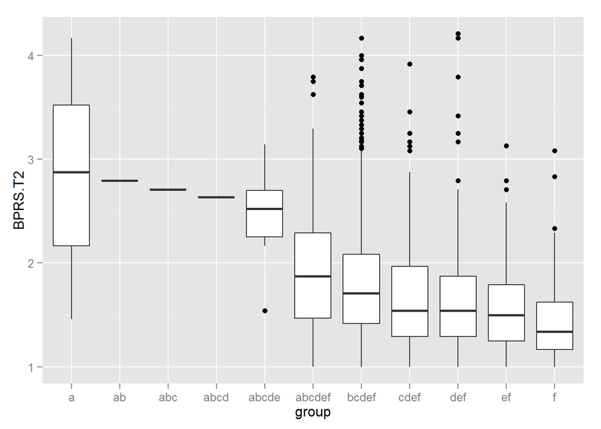

```r
post.hoc.groups <- post.hoc.groups[,c(1,3)]
colnames(post.hoc.groups) <- c("ICD10", "group")
df <- merge(eunomia, post.hoc.groups, "ICD10")
ggplot(aes(y=BPRS.T2, x=group), data=df) + geom_boxplot()
```

### ICD10 as random effect

When ICD10 is coded as a random effect we are not interested in clutering it. When considering random effects we are focused in its distribution not on the effects of particular groups.